# EasyVisa Project

## XGBoost Classifier

```
Training performance:
    Accuracy  Recall  Precision        F1
0  0.837694    0.93     0.8432  0.884476
Testing performance:
    Accuracy    Recall  Precision        F1
0   0.73294  0.856303   0.769827  0.810766
```

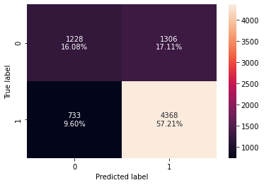

```python
# Fitting the model
xgb_classifier = XGBClassifier(random_state=1, eval_metric="logloss")
xgb_classifier.fit(X_train, y_train)

# Calculating different metrics
xgb_classifier_model_train_perf = model_performance_classification_sklearn(
    xgb_classifier, X_train, y_train
)
print("Training performance:\n", xgb_classifier_model_train_perf)
xgb_classifier_model_test_perf = model_performance_classification_sklearn(
    xgb_classifier, X_test, y_test
)
print("Testing performance:\n", xgb_classifier_model_test_perf)

# Creating confusion matrix
confusion_matrix_sklearn(xgb_classifier, X_test, y_test)
```

- Train Data seems to be bit overfitting
- Train and test are not generalized models.
- Precision value has reduced to 76.9 for Test data and increased to 84.3 for Train data

## Tuning AdaBoostClassifier

```python
# Choose the type of classifier.
abc_tuned = AdaBoostClassifier(random_state=1)

# Grid of parameters to choose from
parameters = {
    # Let's try different max_depth for base_estimator
    "base_estimator": [
        DecisionTreeClassifier(max_depth=1),
        DecisionTreeClassifier(max_depth=2),
    ],
    "n_estimators": np.arange(10, 70, 10),
    "learning_rate": np.arange(0.1, 1, 0.1),
}

# Type of scoring used to compare parameter  combinations
scorer = metrics.make_scorer(metrics.f1_score)

# Run the grid search
grid_obj = GridSearchCV(abc_tuned, parameters, scoring=scorer, cv=5, n_jobs=-1)
grid_obj = grid_obj.fit(X_train, y_train)

# Set the clf to the best combination of parameters
abc_tuned = grid_obj.best_estimator_

# Fit the best algorithm to the data.
abc_tuned.fit(X_train, y_train)
```

```
AdaBoostClassifier(base_estimator=DecisionTreeClassifier(max_depth=2),
                   learning_rate=0.4, n_estimators=20, random_state=1)
```

```
   Accuracy    Recall  Precision        F1
0  0.745677  0.895714   0.764196  0.824745
   Accuracy    Recall  Precision        F1
0  0.743549  0.886493   0.766311  0.822032
```

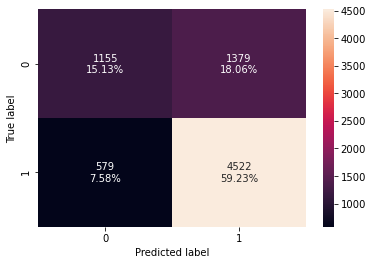

```python
# Calculating different metrics
abc_tuned_model_train_perf = model_performance_classification_sklearn(
    abc_tuned, X_train, y_train
)
print(abc_tuned_model_train_perf)
abc_tuned_model_test_perf = model_performance_classification_sklearn(
    abc_tuned, X_test, y_test
)
print(abc_tuned_model_test_perf)

# Creating confusion matrix
confusion_matrix_sklearn(abc_tuned, X_test, y_test)
```

- We are getting a generalized Test and Train model.
- Precion value has increased a bit to is ~76 for Test and Train data

## Tuning GradientBoostingClassifier

```python
# Choose the type of classifier.
gbc_tuned = GradientBoostingClassifier(
    init=AdaBoostClassifier(random_state=1), random_state=1
)

# Grid of parameters to choose from
parameters = {
    "n_estimators": [100, 150, 200],
    "subsample": [0.8, 0.9],
    "max_features": [0.7, 0.8, 0.9],
}

# Type of scoring used to compare parameter combinations
scorer = metrics.make_scorer(metrics.f1_score)

# Run the grid search
grid_obj = GridSearchCV(gbc_tuned, parameters, scoring=scorer, cv=5, n_jobs=-1)
grid_obj = grid_obj.fit(X_train, y_train)

# Set the clf to the best combination of parameters
gbc_tuned = grid_obj.best_estimator_

# Fit the best algorithm to the data.
gbc_tuned.fit(X_train, y_train)
```

```
GradientBoostingClassifier(init=AdaBoostClassifier(random_state=1),
                           max_features=0.9, n_estimators=150, random_state=1,
                           subsample=0.9)
```

```
Training performance:
    Accuracy    Recall  Precision        F1
0  0.759713  0.877563     0.7872  0.829929
Testing performance:
    Accuracy    Recall  Precision        F1
0  0.746824  0.862968    0.78105  0.819968
```

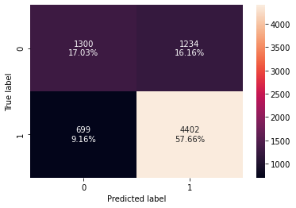

```python
# Calculating different metrics
gbc_tuned_model_train_perf = model_performance_classification_sklearn(
    gbc_tuned, X_train, y_train
)
print("Training performance:\n", gbc_tuned_model_train_perf)
gbc_tuned_model_test_perf = model_performance_classification_sklearn(
    gbc_tuned, X_test, y_test
)
print("Testing performance:\n", gbc_tuned_model_test_perf)

# Creating confusion matrix
confusion_matrix_sklearn(gbc_tuned, X_test, y_test)
```

- We are getting a generalized Test and Train model.
- Precion value has increased a bit to is ~78 for Test and Train data

## Tuning XGBClassifier

```python
# Choose the type of classifier.
xgb_tuned = XGBClassifier(random_state=1, eval_metric="logloss")

# Grid of parameters to choose from
parameters = {
    "n_estimators": [10, 30, 40],
    "scale_pos_weight": [1, 2, 4],
    "subsample": [0.7, 0.9],
    "learning_rate": [0.05, 0.1],
    "colsample_bytree": [0.7, 0.9],
    "colsample_bylevel": [0.5, 0.7],
}

# Type of scoring used to compare parameter combinations
scorer = metrics.make_scorer(metrics.f1_score)

# Run the grid search
grid_obj = GridSearchCV(xgb_tuned, parameters, scoring=scorer, cv=5, n_jobs=-1)
grid_obj = grid_obj.fit(X_train, y_train)

# Set the clf to the best combination of parameters
xgb_tuned = grid_obj.best_estimator_

# Fit the best algorithm to the data.
xgb_tuned.fit(X_train, y_train)
```

```
XGBClassifier(base_score=0.5, booster='gbtree', colsample_bylevel=0.7,
              colsample_bynode=1, colsample_bytree=0.7,
              enable_categorical=False, eval_metric='logloss', gamma=0,
              gpu_id=-1, importance_type=None, interaction_constraints='',
              learning_rate=0.1, max_delta_step=0, max_depth=6,
              min_child_weight=1, missing=nan, monotone_constraints='()',
              n_estimators=30, n_jobs=4, num_parallel_tree=1, predictor='auto',
              random_state=1, reg_alpha=0, reg_lambda=1, scale_pos_weight=1,
              subsample=0.7, tree_method='exact', validate_parameters=1,
              verbosity=None)
```

```
Training performance:
    Accuracy    Recall  Precision        F1
0  0.760274  0.886975   0.783012  0.831757
Testing performance:
    Accuracy   Recall  Precision        F1
0  0.750229  0.87277   0.779685  0.823606
```

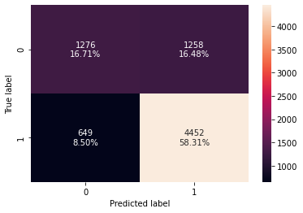

```python
# Calculating different metrics
xgb_tuned_model_train_perf = model_performance_classification_sklearn(
    xgb_tuned, X_train, y_train
)
print("Training performance:\n", xgb_tuned_model_train_perf)
xgb_tuned_model_test_perf = model_performance_classification_sklearn(
    xgb_tuned, X_test, y_test
)
print("Testing performance:\n", xgb_tuned_model_test_perf)

# Creating confusion matrix
confusion_matrix_sklearn(xgb_tuned, X_test, y_test)
```

- XGBClassifier is better after tuning and in Generalized form for test and train data.
- Precision is ~78 better than untuned model.

## Stacking Classifier

```python
estimators = [
    ("Random Forest", rf_tuned),
    ("Gradient Boosting", gbc_tuned),
    ("Decision Tree", dtree_estimator),
]

final_estimator = xgb_tuned

stacking_classifier = StackingClassifier(
    estimators=estimators, final_estimator=final_estimator
)

stacking_classifier.fit(X_train, y_train)
```

```
StackingClassifier(estimators=[('Random Forest',
                                RandomForestClassifier(class_weight={0: 0.35,
                                                                     1: 0.65},
                                                       max_depth=3,
                                                       max_samples=0.7,
                                                       min_impurity_decrease=0.001,
                                                       n_estimators=30,
                                                       random_state=1)),
                               ('Gradient Boosting',
                                GradientBoostingClassifier(init=AdaBoostClassifier(random_state=1),
                                                           max_features=0.9,
                                                           n_estimators=150,
                                                           random_state=1,
                                                           subsample=0.9)),
                               ('Decision...
                                                 gpu_id=-1,
                                                 importance_type=None,
                                                 interaction_constraints='',
                                                 learning_rate=0.1,
                                                 max_delta_step=0, max_depth=6,
                                                 min_child_weight=1,
                                                 missing=nan,
                                                 monotone_constraints='()',
                                                 n_estimators=30, n_jobs=4,
                                                 num_parallel_tree=1,
                                                 predictor='auto',
                                                 random_state=1, reg_alpha=0,
                                                 reg_lambda=1,
                                                 scale_pos_weight=1,
                                                 subsample=0.7,
                                                 tree_method='exact',
                                                 validate_parameters=1,
                                                 verbosity=None))
```

```
Training performance:
    Accuracy   Recall  Precision       F1
0  0.757467  0.88395   0.781617  0.82964
Testing performance:
    Accuracy    Recall  Precision        F1
0  0.744859  0.866889   0.777016  0.819496
```

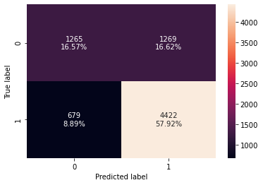

```python
# Calculating different metrics
stacking_classifier_model_train_perf = model_performance_classification_sklearn(
    stacking_classifier, X_train, y_train
)
print("Training performance:\n", stacking_classifier_model_train_perf)
stacking_classifier_model_test_perf = model_performance_classification_sklearn(
    stacking_classifier, X_test, y_test
)
print("Testing performance:\n", stacking_classifier_model_test_perf)

# Creating confusion matrix
confusion_matrix_sklearn(stacking_classifier, X_test, y_test)
```

## Comparing all models

```python
# training performance comparison

models_train_comp_df = pd.concat(
    [
        dtree_model_train_perf.T,
        dtree_estimator_model_train_perf.T,
        rf_estimator_model_train_perf.T,
        rf_tuned_model_train_perf.T,
        bagging_classifier_model_train_perf.T,
        bagging_estimator_tuned_model_train_perf.T,
        ab_classifier_model_train_perf.T,
        abc_tuned_model_train_perf.T,
        gb_classifier_model_train_perf.T,
        gbc_tuned_model_train_perf.T,
        xgb_classifier_model_train_perf.T,
        xgb_tuned_model_train_perf.T,
        stacking_classifier_model_train_perf.T,
    ],
    axis=1,
)
models_train_comp_df.columns = [
    "Decision Tree",
    "Decision Tree Estimator",
    "Random Forest Estimator",
    "Random Forest Tuned",
    "Bagging Classifier",
    "Bagging Estimator Tuned",
    "Adaboost Classifier",
    "Adabosst Classifier Tuned",
    "Gradient Boost Classifier",
    "Gradient Boost Classifier Tuned",
    "XGBoost Classifier",
    "XGBoost Classifier Tuned",
    "Stacking Classifier",
]
print("Training performance comparison:")
models_train_comp_df
```

```
Training performance comparison:
```

|  | Decision Tree | Decision Tree Estimator | Random Forest Estimator | Random Forest Tuned | Bagging Classifier | Bagging Estimator Tuned | Adaboost Classifier | Adabosst Classifier Tuned | Gradient Boost Classifier | Gradient Boost Classifier Tuned | XGBoost Classifier | XGBoost Classifier Tuned | Stacking Classifier |
| --- | --- | --- | --- | --- | --- | --- | --- | --- | --- | --- | --- | --- | --- |
| Accuracy | 1.0 | 0.668089 | 0.999888 | 0.668089 | 0.984729 | 0.668089 | 0.738715 | 0.745677 | 0.755221 | 0.759713 | 0.837694 | 0.760274 | 0.757467 |
| Recall | 1.0 | 1.000000 | 1.000000 | 1.000000 | 0.986050 | 1.000000 | 0.890000 | 0.895714 | 0.876555 | 0.877563 | 0.930000 | 0.886975 | 0.883950 |
| Precision | 1.0 | 0.668089 | 0.999832 | 0.668089 | 0.991047 | 0.668089 | 0.759974 | 0.764196 | 0.782991 | 0.787200 | 0.843200 | 0.783012 | 0.781617 |
| F1 | 1.0 | 0.801023 | 0.999916 | 0.801023 | 0.988543 | 0.801023 | 0.819864 | 0.824745 | 0.827135 | 0.829929 | 0.884476 | 0.831757 | 0.829640 |

```python
# testing performance comparison

models_test_comp_df = pd.concat(
    [
        dtree_model_test_perf.T,
        dtree_estimator_model_test_perf.T,
        rf_estimator_model_test_perf.T,
        rf_tuned_model_test_perf.T,
        bagging_classifier_model_test_perf.T,
        bagging_estimator_tuned_model_test_perf.T,
        ab_classifier_model_test_perf.T,
        abc_tuned_model_test_perf.T,
        gb_classifier_model_test_perf.T,
        gbc_tuned_model_test_perf.T,
        xgb_classifier_model_test_perf.T,
        xgb_tuned_model_test_perf.T,
        stacking_classifier_model_test_perf.T,
    ],
    axis=1,
)
models_test_comp_df.columns = [
    "Decision Tree",
    "Decision Tree Estimator",
    "Random Forest Estimator",
    "Random Forest Tuned",
    "Bagging Classifier",
    "Bagging Estimator Tuned",
    "Adaboost Classifier",
    "Adabosst Classifier Tuned",
    "Gradient Boost Classifier",
    "Gradient Boost Classifier Tuned",
    "XGBoost Classifier",
    "XGBoost Classifier Tuned",
    "Stacking Classifier",
]
print("Testing performance comparison:")
models_test_comp_df
```

```
Testing performance comparison:
```

|  | Decision Tree | Decision Tree Estimator | Random Forest Estimator | Random Forest Tuned | Bagging Classifier | Bagging Estimator Tuned | Adaboost Classifier | Adabosst Classifier Tuned | Gradient Boost Classifier | Gradient Boost Classifier Tuned | XGBoost Classifier | XGBoost Classifier Tuned | Stacking Classifier |
| --- | --- | --- | --- | --- | --- | --- | --- | --- | --- | --- | --- | --- | --- |
| Accuracy | 0.656843 | 0.668107 | 0.724558 | 0.668107 | 0.705043 | 0.668107 | 0.733202 | 0.743549 | 0.746300 | 0.746824 | 0.732940 | 0.750229 | 0.744859 |
| Recall | 0.739071 | 1.000000 | 0.837287 | 1.000000 | 0.782592 | 1.000000 | 0.878651 | 0.886493 | 0.865517 | 0.862968 | 0.856303 | 0.872770 | 0.866889 |
| Precision | 0.745207 | 0.668107 | 0.770382 | 0.668107 | 0.777410 | 0.668107 | 0.759661 | 0.766311 | 0.779209 | 0.781050 | 0.769827 | 0.779685 | 0.777016 |
| F1 | 0.742126 | 0.801036 | 0.802442 | 0.801036 | 0.779992 | 0.801036 | 0.814835 | 0.822032 | 0.820098 | 0.819968 | 0.810766 | 0.823606 | 0.819496 |

- Both Tuned Models of Gradient Boost Classifier and XGBoostClassifier have done pretty well among all the other given models.
- These models are giving a generalized perfoirmance compared to other models.
- There is also no overfitting of Train data.
- The Precision score is around ~78 which is good.

## Feature importance of Gradient Boost Classifier

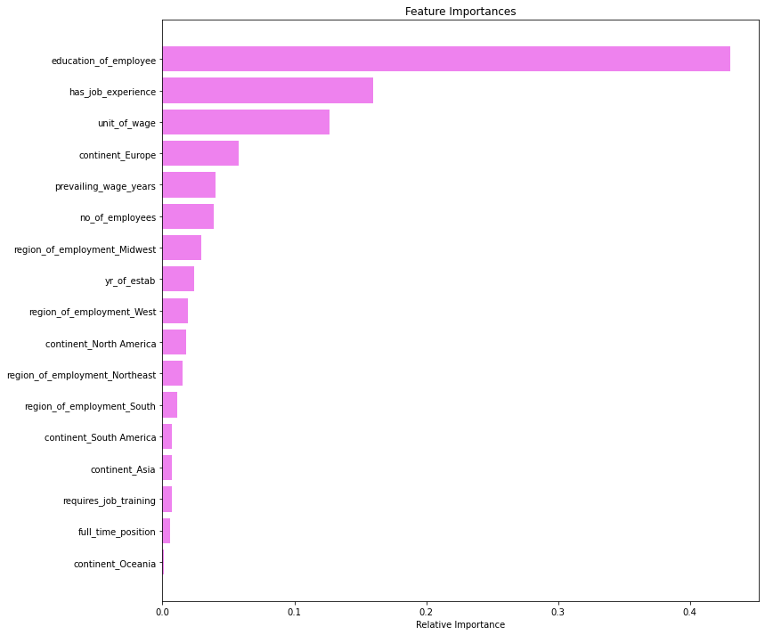

```python
feature_names = X_train.columns
importances = gbc_tuned.feature_importances_
indices = np.argsort(importances)

plt.figure(figsize=(12, 12))
plt.title("Feature Importances")
plt.barh(range(len(indices)), importances[indices], color="violet", align="center")
plt.yticks(range(len(indices)), [feature_names[i] for i in indices])
plt.xlabel("Relative Importance")
plt.show()
```

## Actionable Insights and Recommendations

- The three most important features that we have found affecting the Visa Certification are education_of_employee, has_job_experience and unit_of_wage.
- Companies should Increase wage and keep the minimum wage around 50000. We have found that there are more Denied cases for wage<50000.
- The wage should be paid out yearly and if possible hourly wages should be stopped. Employees with wages paid in year have 70% chances of certification whereas for hourly wages it is only 35%.
- Focus more on recruiting employees from Europe and Africa where there are higher chances of Visa Certification.
- Find Reasons why there might be less certifications for employees from other continents and work upon them.
- Recruit more and more highly educated employees with Doctorate and Master's as they have high chances of visa certifications.
- Mention Doctorate/Masters as one the required qualifications in the job description so that more and more highly education employees can apply.
- Job experience plays an important role in Visa Certification. 74% employees with job experience have Visa Certification compared to 56% employees with no job experience.
- Mention Job experience as one the required qualifications in the job description so that more and more highly qualified employees can apply.
- Companies in Midwest Region have highest Certification cases with 76%. Companies in Island region have the least Certification cases with 60%.
- If companies can open their new offices in Midwest region, they may get more employee with Visa Certification.

## Let's have a quick final overview of the data using the pandas profiling library.

```python
# import pandas_profiling
from pandas_profiling import ProfileReport

# Use the original dataframe, so that original features are considered
prof = ProfileReport(data)
# to view report created by pandas profile
prof
```

[interactive chart not shown]